# Data Visualization

## Stats 141B

## Lecture 15

[Chloropleth](https://media.sacbee.com/static/newsroom/infantdaycare6.png) map

- Could just report a stat, "the average cost of daycare in 2014 was 13,300 USD"
- Instead allows you to ask questions, "what is the average cost of childcare where I live?"
- Could contain implicit distortions of the data, chloropleth map suggests that larger geographic areas have higher weight

## Data Visualization

### Old way

- Named plots:
  - histogram, scatterplot, time series plot, etc.
- Increasingly complicated named plots (e.g. Hexbin plot with marginal distributions)
- Lacks versitility: many options as you build a plot, a named plot can only give you so many options

### New way

- Deconstructing the plot: understand and name the components
- Grammar of graphics: rules that guide how these fit together

## Data Visualization: Python landscape

### Low level drawing

- Matplotlib

### Named plots

- Pyplot
- Seaborn
- Pandas dataframe.plot

### Grammar of graphics

- Plotnine

### Interactive

- Mpld3
- Plotly
- Bokeh

### Why visualize data at all?

Arguments for:

- Let's people see the data
- The eye can extract it's own statistics and conclusions
- Explore the data, guide statistical analysis
- More impactful/engaging statistical content

Arguments against:

- Can mislead people without being an outright lie
- Often is a graphical design exercise / data is not the focus anymore
- Humans find patterns where there are none

[figure not shown]

- https://www.sacbee.com/news/local/transportation/article151302502.html

### How to correct this issue?

- add textual context, should alert the reader to the issue of un-observed baseline.
- more educated data visualization viewers
- do not overexaggerate conclusions: "where Sacramento bicyclists are hit most often"
- choose a different visualization / scrap the analysis altogether

### Conclusions

- context matters: textual and viewer experience
- visualization does not overcome statistical issues: multiple testing problems, spurious patterns, etc.

### Visualization is only as good as statistics

- hidden multiple tests
- implied / unreported baselines
- possible confounding variables

[figure not shown]

- http://tylervigen.com/spurious-correlations

## Graphical excellence

- shows the data
- induce the viewer to think about substance rather than methodology
- avoid distortion of data
- present many numbers in small space
- make large datasets coherent
- encourage the eye to compare different pieces of data
- reveal the data at several levels of detail
- serve a reasonably clear purpose: description, exploration, tabulation, or decoration
- be closely integrated with the statistical and verbal descriptions of a data set

(The Visual Display of Quantitative Info., Tufte)

### Deconstructing the plot

1. geometric objects, and aesthetic elements
2. scales and coordinate systems,
3. annotation for the plot.

[figure not shown]

### Hubble plot

- the data points and regression lines are all geometric objects
- the scales and coordinate systems are represented by the guide lines and ticks
- the annotation is the axis labels.

### Elements of Plot

- Geometric objects can be points (as in a scatter plot), lines (as in regression line), or polygons (as in the counties in the chloropleth map).
- These objects have various aesthetics, such as the position of a point or the width of a line.
- One plot may have many layers with different layers containing different geometric objects.
- A scale will map the data to the aesthetics.

### http://rhythm-of-food.net/

- Read the instructions (how to read this visualization)
- To play this game:
  - Look at the visualization
  - Extract conclusions quickly

[figure not shown]

### Common distortions in visualization

- in our scatterplots, the aesthetic mappings to the size of a point geom using radius instead of area to calculate the scale (area does not match the quantity)
- remove or lower the X-axis from a bar chart which makes the area of the bar appear larger than the actual number that they represent
- graphics can be distracting and some graphic design elements can detract from the display of information

[figure not shown]

## Ohio Presidential Election 2016

## Things that I would like to know

- Geographic location of different voters
- Political polarization
- Effect of 3rd party candidates
- Were the voting systems hacked?

```python
## Read in data
OH = pd.read_csv('data/OHvotes.csv')
OH.head()
```

|  | County Name | Precinct Name | Precinct Code | Region Name | Media Market | Registered Voters | Total Voters | Turnout Percentage | James Jerome Bell (WI)* | Michael Bickelmeyer (WI)* | ... | Joseph Maldonado (WI)* | Michael Andrew Maturen (WI)* | Evan McMullin (WI)* | Monica Moorehead (WI)* | Joe Schriner (WI)* | Mike Smith (WI)* | Jill Stein (G) | Josiah R. Stroh (WI)* | Douglas W. Thomson (WI)* | Donald J. Trump (R) |
| --- | --- | --- | --- | --- | --- | --- | --- | --- | --- | --- | --- | --- | --- | --- | --- | --- | --- | --- | --- | --- | --- |
| 0 | Adams | BRATTON TOWNSHIP | AAA | Southwest | Cincinnati | 923 | 661 | 71.61% | 0 | 0 | ... | 0 | 0 | 0 | 0 | 0 | 0 | 4 | 0 | 0 | 532 |
| 1 | Adams | BRUSH CREEK TOWNSHIP | AAB | Southwest | Cincinnati | 768 | 514 | 66.93% | 0 | 0 | ... | 0 | 0 | 0 | 0 | 0 | 0 | 0 | 0 | 0 | 390 |
| 2 | Adams | LOCUST GROVE | AAD | Southwest | Cincinnati | 684 | 522 | 76.32% | 0 | 0 | ... | 0 | 0 | 0 | 0 | 0 | 0 | 4 | 0 | 0 | 408 |
| 3 | Adams | GREEN TOWNSHIP | AAE | Southwest | Cincinnati | 409 | 259 | 63.33% | 0 | 0 | ... | 0 | 0 | 0 | 0 | 0 | 0 | 1 | 0 | 0 | 176 |
| 4 | Adams | JEFFERSON TOWNSHIP | AAG | Southwest | Cincinnati | 537 | 351 | 65.36% | 0 | 0 | ... | 0 | 0 | 0 | 0 | 0 | 0 | 2 | 0 | 0 | 258 |

5 rows × 31 columns

```python
OH.info()
```

```
<class 'pandas.core.frame.DataFrame'>
RangeIndex: 8887 entries, 0 to 8886
Data columns (total 31 columns):
 #   Column                        Non-Null Count  Dtype
---  ------                        --------------  -----
 0   County Name                   8887 non-null   object
 1   Precinct Name                 8887 non-null   object
 2   Precinct Code                 8887 non-null   object
 3   Region Name                   8887 non-null   object
 4   Media Market                  8887 non-null   object
 5   Registered Voters             8887 non-null   object
 6   Total Voters                  8887 non-null   object
 7   Turnout Percentage            8887 non-null   object
 8   James Jerome Bell (WI)*       8887 non-null   int64
 9   Michael Bickelmeyer (WI)*     8887 non-null   int64
```

[output cut: 23 more lines]

```python
## Why are the Clinton votes objects and not ints?
## try casting as ints

for val in OH['Hillary Clinton (D)']:
    try:
        int(val)
    except:
        print(val)
```

```
1,692
1,048
1,024
1,035
1,196
1,026
```

```python
## set thousands arg

OH = pd.read_csv('data/OHvotes.csv',thousands=',')
OH.info()
```

```
<class 'pandas.core.frame.DataFrame'>
RangeIndex: 8887 entries, 0 to 8886
Data columns (total 31 columns):
 #   Column                        Non-Null Count  Dtype
---  ------                        --------------  -----
 0   County Name                   8887 non-null   object
 1   Precinct Name                 8887 non-null   object
 2   Precinct Code                 8887 non-null   object
 3   Region Name                   8887 non-null   object
 4   Media Market                  8887 non-null   object
 5   Registered Voters             8887 non-null   int64
 6   Total Voters                  8887 non-null   int64
 7   Turnout Percentage            8887 non-null   object
 8   James Jerome Bell (WI)*       8887 non-null   int64
 9   Michael Bickelmeyer (WI)*     8887 non-null   int64
```

[output cut: 23 more lines]

```python
OH = OH.set_index(['County Name','Precinct Name']) # set indices
```

```python
cols = OH.columns.str.replace(' ','_')
cols = cols.str.replace('.','')
cols = cols.str.replace('*','')
cols = cols.str.replace('_\(.+\)','')
cols = cols.str.lower()
cols
```

```
Index(['precinct_code', 'region_name', 'media_market', 'registered_voters',
       'total_voters', 'turnout_percentage', 'james_jerome_bell',
       'michael_bickelmeyer', 'darrell_l_castle', 'hillary_clinton',
       'richard_duncan', 'cherunda_fox', 'ben_hartnell', 'tom_hoefling',
       'bruce_e_jaynes', 'gary_johnson', 'chris_keniston', 'barry_kirschner',
       'laurence_kotlikoff', 'joseph_maldonado', 'michael_andrew_maturen',
       'evan_mcmullin', 'monica_moorehead', 'joe_schriner', 'mike_smith',
       'jill_stein', 'josiah_r_stroh', 'douglas_w_thomson', 'donald_j_trump'],
      dtype='object')
```

```python
OH.columns = cols
```

```python
OH[['registered_voters','total_voters']].describe()
```

|  | registered_voters | total_voters |
| --- | --- | --- |
| count | 8887.000000 | 8887.000000 |
| mean | 884.553280 | 630.993699 |
| std | 283.843033 | 218.134518 |
| min | 2.000000 | 2.000000 |
| 25% | 697.500000 | 476.000000 |
| 50% | 874.000000 | 623.000000 |
| 75% | 1055.000000 | 770.000000 |
| max | 3586.000000 | 2434.000000 |

```python
## Let's remove some candidates

candidates = OH.columns.values[9:] # isolate candidate names
candidates
```

```
array(['hillary_clinton', 'richard_duncan', 'cherunda_fox',
       'ben_hartnell', 'tom_hoefling', 'bruce_e_jaynes', 'gary_johnson',
       'chris_keniston', 'barry_kirschner', 'laurence_kotlikoff',
       'joseph_maldonado', 'michael_andrew_maturen', 'evan_mcmullin',
       'monica_moorehead', 'joe_schriner', 'mike_smith', 'jill_stein',
       'josiah_r_stroh', 'douglas_w_thomson', 'donald_j_trump'],
      dtype=object)
```

```python
## add no vote for pres
OH['no_pres'] = OH['total_voters'] - OH[candidates].sum(axis=1)
candidates = candidates.tolist() + ['no_pres']
```

```python
## Quick look at percentages
totals = OH[candidates].sum()
total_percs = totals / totals.sum()
total_percs
```

```
hillary_clinton           0.426947
richard_duncan            0.004322
cherunda_fox              0.000000
ben_hartnell              0.000000
tom_hoefling              0.000000
bruce_e_jaynes            0.000000
gary_johnson              0.031118
chris_keniston            0.000000
barry_kirschner           0.000000
laurence_kotlikoff        0.000000
joseph_maldonado          0.000000
michael_andrew_maturen    0.000000
evan_mcmullin             0.000000
monica_moorehead          0.000000
joe_schriner              0.000000
mike_smith                0.000000
jill_stein                0.008251
josiah_r_stroh            0.000000
douglas_w_thomson         0.000000
donald_j_trump            0.506631
no_pres                   0.022731
dtype: float64
```

```python
total_percs[total_percs > 0.001] # serious candidates
```

```
hillary_clinton    0.426947
richard_duncan     0.004322
gary_johnson       0.031118
jill_stein         0.008251
donald_j_trump     0.506631
no_pres            0.022731
dtype: float64
```

```python
## Isolate the candidates with more than .1% of vote
ser_cands = total_percs[total_percs > 0.001].index.values.tolist()
keep_cols = ['total_voters','registered_voters'] + ser_cands
OH = OH[keep_cols]
OHsum = OH.sum()
```

```python
## percent of registered that voted
OHsum['total_voters'] / OHsum['registered_voters']
```

```
0.713347305217831
```

```python
## extract percentages
OH_percs = OH[keep_cols].transform(lambda x: x / OH['total_voters'])
OH = OH.join(OH_percs,rsuffix="_perc")
```

### State-wide obervations for OH 2016

- 8887 Precinct with average 631 voters
- 50.6% of voters voted for Trump, 42.7% for Hillary
- 5.6 Mill people voted, 71.3% of registered voters
- Third party and independent candidates are
  - Gary Johnson: 3.1%
  - Jill Stein: 0.83%
  - Richard Duncan: 0.43%
- 2.2% of those that vote did not vote for president

### Further questions

- Geographic location of different voters
- Political polarization
- Effect of 3rd party candidates
- Were the voting systems hacked?

```python
## Create categorical variables for red-blue swing and number of registered voters
OH['swing'] = OH.eval('(donald_j_trump - hillary_clinton) / total_voters')
OH['swing_cat'] = pd.qcut(OH['swing'],3,labels=['blue','purple','red'])
OH['reg_cat'] = pd.qcut(OH['registered_voters'],3,labels=['small','med','large'])
```

```python
OH[['swing_cat','swing']].groupby('swing_cat').describe()
```

| swing_cat | swing count | swing mean | swing std | swing min | swing 25% | swing 50% | swing 75% | swing max |
| --- | --- | --- | --- | --- | --- | --- | --- | --- |
| blue | 2963.0 | -0.404164 | 0.299395 | -0.985130 | -0.657886 | -0.340479 | -0.135942 | -0.005208 |
| purple | 2962.0 | 0.164581 | 0.089941 | -0.005155 | 0.092293 | 0.166773 | 0.240609 | 0.317901 |
| red | 2962.0 | 0.476933 | 0.105792 | 0.317935 | 0.390612 | 0.462117 | 0.552447 | 1.000000 |

```python
OH[['swing_cat','total_voters']].groupby('swing_cat').describe()
```

| swing_cat | total_voters count | total_voters mean | total_voters std | total_voters min | total_voters 25% | total_voters 50% | total_voters 75% | total_voters max |
| --- | --- | --- | --- | --- | --- | --- | --- | --- |
| blue | 2963.0 | 630.201147 | 216.101325 | 3.0 | 476.00 | 618.0 | 760.5 | 2434.0 |
| purple | 2962.0 | 664.137407 | 213.645345 | 25.0 | 515.00 | 662.0 | 803.0 | 1387.0 |
| red | 2962.0 | 598.642809 | 219.749601 | 2.0 | 445.25 | 588.0 | 737.0 | 1313.0 |

```python
## pivot table will aggregate single variable grouped by two variables
## result is a contingency table
swing_reg = pd.pivot_table(OH,values='total_voters',
                           index='reg_cat',columns='swing_cat',aggfunc='sum')
swing_reg
```

| swing_cat reg_cat | blue | purple | red |
| --- | --- | --- | --- |
| small | 273696 | 388116 | 584333 |
| med | 639908 | 669252 | 549580 |
| large | 953682 | 909807 | 639267 |

```python
## Chi^2 stat is large if cat variables are dependent
chi2, p_val, _, exp_mat = stats.chi2_contingency(swing_reg)
print("Chi-squared statistic: {}\nP-value: {}".format(chi2,p_val))
```

```
Chi-squared statistic: 196884.7458095867
P-value: 0.0
```

```python
## More informative to look at deviation of actual from expected under indep.
(swing_reg - exp_mat) / np.sqrt(exp_mat)
```

| swing_cat reg_cat | blue | purple | red |
| --- | --- | --- | --- |
| small | -219.286188 | -74.163391 | 303.144971 |
| med | 26.650829 | 21.301871 | -49.785791 |
| large | 131.766854 | 33.973991 | -171.002439 |

### Geographic observations

- In precincts with few registered voters, there is a strong tendency to vote Trump
- In precincts with more registed voters, there is a weaker but noticable tendency to vote Clinton

Does fewer/more registered voters correspond to population density?

> It is important to be precise in conclusions: number of registered voters is not the same as the population density.

### County level analysis of the election results

- In which counties did people vote for Trump/Clinton?
- What are the population densities?

```python
## Aggregate by counties and recompute swing vars
OH_counties = OH[keep_cols].groupby(level=0).sum()
OH_counties['swing'] = OH_counties.eval('(donald_j_trump - hillary_clinton) / total_voters')
OH_counties['swing_cat'] = pd.cut(OH_counties['swing'],[-1,-.1,.1,1],labels=['blue','purple','red'])
```

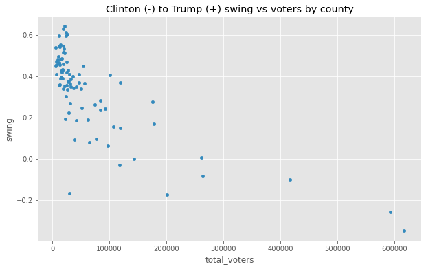

```python
OH_counties.plot('total_voters','swing',kind='scatter',
                 title='Clinton (-) to Trump (+) swing vs voters by county')
```

```python
## Extract area dataset
OHarea = pd.read_excel('data/OHarea.xlsx')
OHarea = OHarea.set_index('County')
OHarea.columns = ['area']
```

```python
## Join datasets and compute density
OH_counties = OH_counties.join(OHarea)
OH_counties['voter_density'] = OH_counties.eval('registered_voters / area')
```

```python
OH_counties[['swing_cat','total_voters','voter_density']].groupby('swing_cat').mean()
```

| swing_cat | total_voters | voter_density |
| --- | --- | --- |
| blue | 371851.20 | 1187.141751 |
| purple | 133221.25 | 414.347543 |
| red | 35768.20 | 109.925027 |

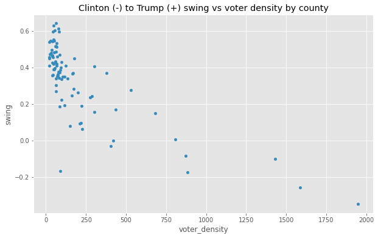

```python
OH_counties.plot('voter_density','swing',kind='scatter',
                 title='Clinton (-) to Trump (+) swing vs voter density by county')
```

```python
## What is this outlier?
Ath = OH_counties.query('swing < 0 and voter_density < 250')
Ath
```

| County Name | total_voters | registered_voters | hillary_clinton | richard_duncan | gary_johnson | jill_stein | donald_j_trump | no_pres | swing | swing_cat | area | voter_density |
| --- | --- | --- | --- | --- | --- | --- | --- | --- | --- | --- | --- | --- |
| Athens | 30042 | 45418 | 16370 | 130 | 1012 | 539 | 11354 | 637 | -0.166966 | blue | 503.6 | 90.186656 |

```python
## Trumpland
OH_counties.query('swing > 0.55')
```

| County Name | total_voters | registered_voters | hillary_clinton | richard_duncan | gary_johnson | jill_stein | donald_j_trump | no_pres | swing | swing_cat | area | voter_density |
| --- | --- | --- | --- | --- | --- | --- | --- | --- | --- | --- | --- | --- |
| Auglaize | 24019 | 31666 | 3980 | 132 | 701 | 112 | 18658 | 436 | 0.611100 | red | 401.39 | 78.890854 |
| Darke | 25821 | 34063 | 4470 | 123 | 649 | 149 | 20012 | 418 | 0.601913 | red | 598.10 | 56.952015 |
| Holmes | 11654 | 17938 | 1788 | 62 | 374 | 53 | 8720 | 657 | 0.594817 | red | 422.53 | 42.453790 |
| Mercer | 22053 | 28731 | 3384 | 120 | 562 | 110 | 17506 | 371 | 0.640366 | red | 462.45 | 62.127798 |
| Putnam | 19161 | 23507 | 2922 | 119 | 638 | 72 | 14961 | 449 | 0.628307 | red | 482.52 | 48.717152 |
| Shelby | 24116 | 33984 | 4243 | 132 | 594 | 125 | 18590 | 432 | 0.594916 | red | 407.68 | 83.359498 |
| Van Wert | 14062 | 19668 | 2697 | 69 | 429 | 105 | 10469 | 293 | 0.552695 | red | 409.16 | 48.069215 |

### County level population conclusions

- Split the data by clinton-trump swing:
  - blue: > 10% swing for Clinton
  - red: > 10% swing for Trump
  - purple: in between
- Blue counties have average of 371,851 voters
- Red counties have average of 35,768 voters
- Blue counties have roughly 10 times the population density of red counties

Other observations:

- Athens (Ohio University) is very blue and rural (outlier)
- Northwestern counties are very red and rural (extreme)

```python
def comp_cands(cand1,cand2):
    """Scatter plot comparing candidates"""
    candperc1, candperc2 = cand1 + "_perc", cand2 + "_perc"
    OH.plot(candperc1,candperc2,color='b',s = OH['total_voters']/50,edgecolors='white',kind='scatter')
    plt.xlabel(cand1)
    plt.ylabel(cand2)
    plt.title("The precinct level relationship between vote ratio for candidates")
    plt.show()
```

### Third Party Candidates

- What was the effect by third party candidates?
- How strong is this effect?

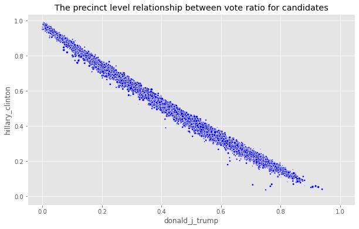

```python
comp_cands('donald_j_trump', 'hillary_clinton')
```

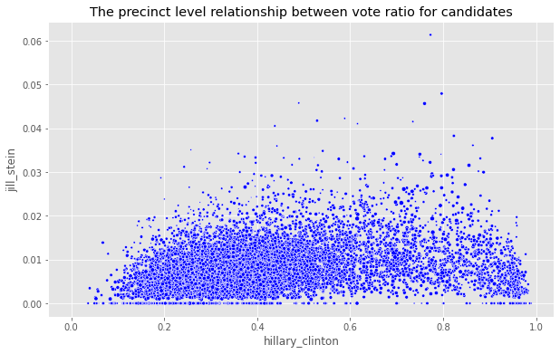

```python
comp_cands('hillary_clinton','jill_stein')
```

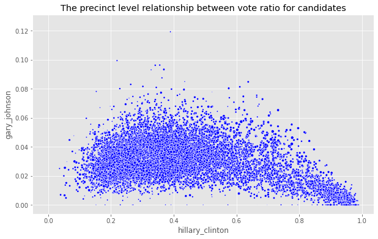

```python
comp_cands('hillary_clinton','gary_johnson')
```

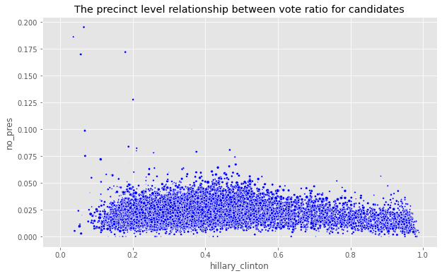

```python
comp_cands('hillary_clinton','no_pres')
```

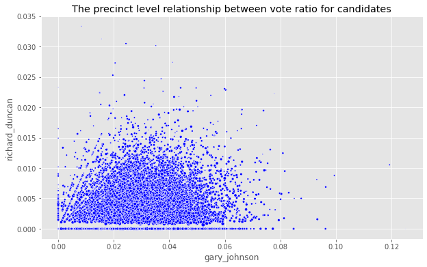

```python
comp_cands('gary_johnson','richard_duncan')
```

```python
## Compute Kendall Tau stats
def cand_tau(cand1,cand2):
    """Kendalls tau between candidates"""
    candperc1, candperc2 = cand1 + "_perc", cand2 + "_perc"
    return stats.kendalltau(OH[candperc1],OH[candperc2])


candidates = OH.columns.values[2:8]
taus = pd.DataFrame(({cand2: cand_tau(cand1,cand2)[0] \
                      for cand2 in candidates} for cand1 in candidates),index=candidates)
```

```python
taus
```

|  | hillary_clinton | richard_duncan | gary_johnson | jill_stein | donald_j_trump | no_pres |
| --- | --- | --- | --- | --- | --- | --- |
| hillary_clinton | 1.000000 | -0.130345 | -0.117481 | 0.206897 | -0.942419 | -0.015571 |
| richard_duncan | -0.130345 | 1.000000 | 0.054683 | 0.057300 | 0.116111 | -0.024804 |
| gary_johnson | -0.117481 | 0.054683 | 1.000000 | 0.099585 | 0.075190 | 0.088185 |
| jill_stein | 0.206897 | 0.057300 | 0.099585 | 1.000000 | -0.227613 | -0.033595 |
| donald_j_trump | -0.942419 | 0.116111 | 0.075190 | -0.227613 | 1.000000 | -0.012731 |
| no_pres | -0.015571 | -0.024804 | 0.088185 | -0.033595 | -0.012731 | 1.000000 |

### Causal effects of voting systems on Clinton-Trump swing?

There was serious public concern about the hacking of certain voting system. Particularly, voting systems such as the Accuvote TS are touch screens that runs off of Windows CE and maintain the votes in memory. These have been noted to be vunerable, as could any voting systems where a computer is involved (including optical scanners). I am interested to see if there is evidence in the voting record of widespread hacking.

```python
## Extract and merge voting system data

OH_machine = pd.read_excel('data/OHmachines.xlsx',dtype='category',header=None)
OH_machine = OH_machine.rename(columns = {0:"County Name", 1:"system"})
OH_machine = OH_machine.set_index("County Name")
```

```python
OH_machine.head()
```

| County Name | system |
| --- | --- |
| Williams | Hart eScan |
| Defiance | Premier AccuVote-TSX |
| Paulding | Premier AccuVote-TSX |
| Van Wert | Premier AccuVote |
| Mercer | Premier AccuVote-TSX |

```python
OH_machine['system'].unique() # unique values for series
```

```
['Hart eScan', 'Premier AccuVote-TSX ', 'Premier AccuVote', ' ES&S Model 100 ', '** Multiple ES&S Optical Scanners **', 'ES&S DS200', 'ES&S iVotronic ', ' Dominion', ' ES&S DS200', ' Unisyn OpenElect']
Categories (10, object): [' Dominion', ' ES&S DS200', ' ES&S Model 100 ', ' Unisyn OpenElect', ..., 'ES&S iVotronic ', 'Hart eScan', 'Premier AccuVote', 'Premier AccuVote-TSX ']
```

```python
## clean and join
OH_machine['system'] = OH_machine['system'].str.strip() # noticed this issue by looking at data
OH_counties = OH_counties.join(OH_machine)
```

```python
## Group by system and sum, recompute swing, voter density
sys_cty_comp = OH_counties.groupby('system').sum()
sys_cty_comp['swing'] = sys_cty_comp.eval('(donald_j_trump - hillary_clinton) / total_voters')
sys_cty_comp['voter_density'] = sys_cty_comp.eval('registered_voters / area')
```

```python
sys_cty_comp[['swing','voter_density']]
```

| system | swing | voter_density |
| --- | --- | --- |
| ** Multiple ES&S Optical Scanners ** | 0.611100 | 78.890854 |
| Dominion | 0.391921 | 60.026588 |
| ES&S DS200 | -0.147699 | 385.701593 |
| ES&S Model 100 | 0.216150 | 127.417605 |
| ES&S iVotronic | -0.090957 | 390.430986 |
| Hart eScan | -0.079225 | 731.759143 |
| Premier AccuVote | 0.421064 | 64.798846 |
| Premier AccuVote-TSX | 0.197850 | 160.888202 |
| Unisyn OpenElect | 0.594817 | 42.453790 |

### Does this mean that the election was hacked?

- Percent swing is highly dependent on election system!
- BUT so is voter density

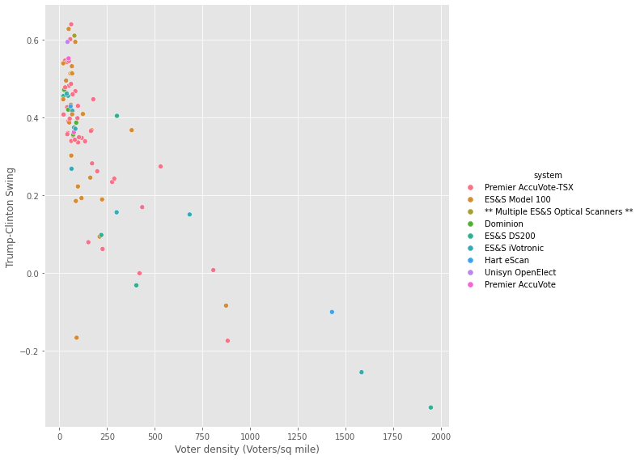

```python
## use Seaborn to plot these three vars

sns.pairplot(x_vars=['voter_density'], y_vars=['swing'], \
             data=OH_counties, hue='system', height=8)
plt.xlabel('Voter density (Voters/sq mile)')
plt.ylabel('Trump-Clinton Swing')
plt.show()
```

### Final conclusions

1. Election outcome in a county is highly dependent on the voter density (voters/sqr. mile) with more rural areas reliably voting Republican (except Athens county)
2. Third party candidate votes are weakly associated with the election outcome, with red precincts tending to vote more for Johnson, and blue precincts tending toward Stein.
3. There is insufficient statistical evidence for a causal effect of voting system on the election outcome.